# Predictive Power Comparison

Jingjing Tang

## MSA Level Analysis

The difference between this analysis and the previous MSA level predictive power comparison is that, here we consider a larger geographic scope. The intersection of MSAs available for DV, FB CLI and FB CLI-in-community from 2020-05-06 to 2020-10-08 is considered. MSAs with no data reported by GS indicators are assigned with a value 0.

### Prediction Preparation

Here we use code liberally borrowed from a [blog post](https://github.com/cmu-delphi/delphi-blog/blob/main/content/post/2020-09-21-forecast-demo.Rmd) to perform a prediction task.

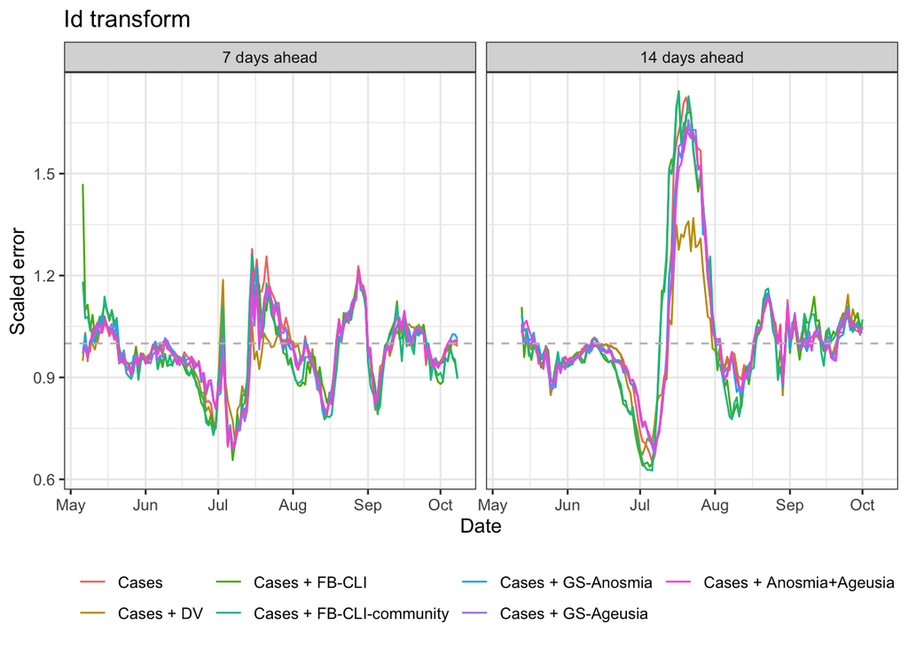

Test period: 2020-05-06 to 2020-10-08 , common time period

| Model | Target | Median scaled error | Test days |
| --- | --- | --- | --- |
| Cases | 7 days ahead | 0.970 | 156 |
| Cases + DV | 7 days ahead | 0.967 | 156 |
| Cases + FB-CLI | 7 days ahead | 0.956 | 156 |
| Cases + FB-CLI-community | 7 days ahead | 0.954 | 156 |
| Cases + GS-Anosmia | 7 days ahead | 0.970 | 156 |
| Cases + GS-Ageusia | 7 days ahead | 0.967 | 156 |
| Cases + Anosmia+Ageusia | 7 days ahead | 0.966 | 156 |
| Cases | 14 days ahead | 0.998 | 142 |
| Cases + DV | 14 days ahead | 0.991 | 142 |
| Cases + FB-CLI | 14 days ahead | 0.985 | 142 |
| Cases + FB-CLI-community | 14 days ahead | 0.982 | 142 |
| Cases + GS-Anosmia | 14 days ahead | 0.993 | 142 |
| Cases + GS-Ageusia | 14 days ahead | 0.990 | 142 |
| Cases + Anosmia+Ageusia | 14 days ahead | 0.991 | 142 |

“Are these differences in median scaled errors significant? It’s hard to say [for certain, given the spatial and temporal dependence of the data], but some basic hypothesis testing suggests that they probably are: below we conduct a sign test for whether the difference in the “Cases” model’s scaled error and each other model’s scaled error is centered at zero" ([source](https://delphi.cmu.edu/blog/2020/09/21/can-symptoms-surveys-improve-covid-19-forecasts/)).

| Comparison | Target | P-value |
| --- | --- | --- |
| Cases vs Cases + DV | 7 days ahead | 0.0000000 |
| Cases vs Cases + DV | 14 days ahead | 0.0000000 |
| Cases vs Cases + FB-CLI | 7 days ahead | 0.0000000 |
| Cases vs Cases + FB-CLI | 14 days ahead | 0.0000000 |
| Cases vs Cases + FB-CLI-community | 7 days ahead | 0.0000000 |
| Cases vs Cases + FB-CLI-community | 14 days ahead | 0.0000000 |
| Cases vs Cases + GS-Anosmia | 7 days ahead | 0.9999655 |
| Cases vs Cases + GS-Anosmia | 14 days ahead | 0.0000000 |
| Cases vs Cases + GS-Ageusia | 7 days ahead | 0.7135088 |
| Cases vs Cases + GS-Ageusia | 14 days ahead | 0.0013103 |
| Cases vs Cases + Anosmia+Ageusia | 7 days ahead | 0.0278706 |
| Cases vs Cases + Anosmia+Ageusia | 14 days ahead | 0.0000000 |

“To mitigate the dependence across time (which intuitively seems to matter more than that across space), we recomputed these tests in a stratified way, where for each day we run a sign test on the scaled errors between two models over all [geographic regions]. The results are plotted as histograms below”, where one count corresponds to one prediction date ([source](https://delphi.cmu.edu/blog/2020/09/21/can-symptoms-surveys-improve-covid-19-forecasts/)).

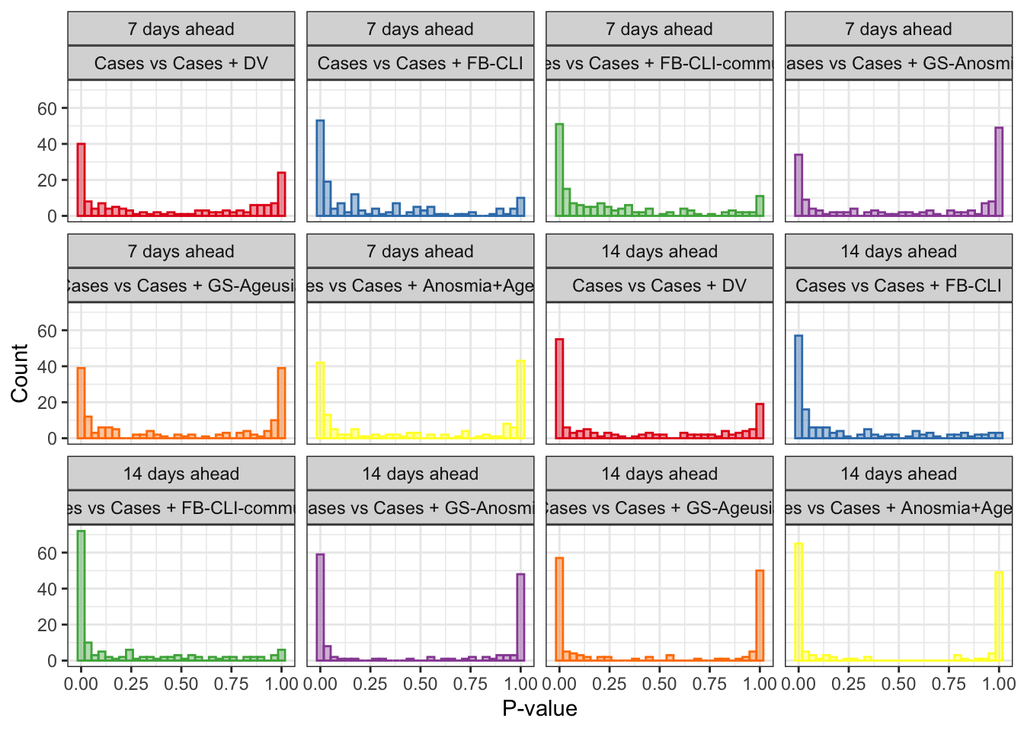

Similar as what we got at county level, 14-day ahead comparisons look *more* significant across all alternative models. So it appears that additional predictors, especially GS, are useful for farther-future predictions, rather than near-future where number of cases is largely sufficient.

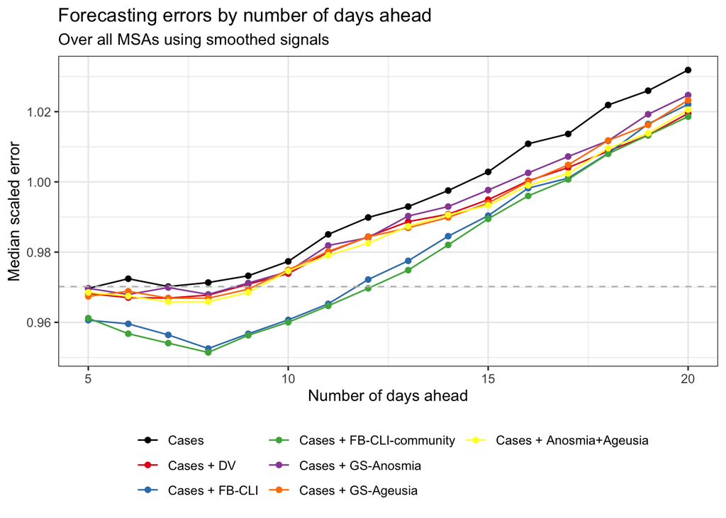

We got pretty simialr result as what we see in the county level analysis. The models containing GS outperform the Cases only model and the Cases + GS A+ A model is as competitive as the Cases + DV signals. And Cases + FB CLI and Cases + FB CLI-in-community models largely outperform other models.